# Statistical analysis for F2 sd (mid and onset)

Mohammad Abuoudeh *Al-Hussein Bin Talal University

10 septembre 2026

# 1 Introduction

This document serves as a reference for the statistical analysis workflow, from importing acoustic data to selecting linear mixed models (LMMs) and visualizing marginal effects.

## 1.1 Data preparation

### 1.1.1 Loading essential packages

```r
library(dplyr)
library(tidyr)
library(lme4)
library(lmerTest)   # p-values pour lmer
library(emmeans)
library(ggplot2)
library(patchwork)
```

### 1.1.2 Loading and data processing

```r
### Charger les données .csv des de l'expérience sur les variations de débit de parole en arabe jordanien collectées .... 10 locuteurs.
Arabic <- read.csv("SpeakingRate24.csv")

#### Traitements de dataframe

Arabic <- subset(Arabic, select = -Arabic_phrase) ### Supprimer la colonne des phrases en arabe pour éviter les problèmes avec PdfLaTex lors de la compilation LaTex R. Sinon, utiliser XeLaTex pour l'écriture arabe.
Arabic$CVC <- gsub(' ', '', Arabic$CVC)#supprimer les espaces
Arabic$V <- gsub(' ', '', Arabic$V)#supprimer les espaces
Arabic$Length <- gsub(' ', '', Arabic$Length)#supprimer les espaces

Arabic$f0ons <- as.integer(gsub('--undefined--', NA, Arabic$f0ons))
Arabic$f0mid <- as.integer(gsub('--undefined--', NA, Arabic$f0mid))
Arabic$f0off <- as.integer(gsub('--undefined--', NA, Arabic$f0off))


Arabic <- mutate_if(Arabic, is.character, as.factor) ## Transformer tous les variables de type "character" à des facteurs.
#Arabic <- filter(Arabic, V!="e:" & V!="o:")
Arabic$V = factor(Arabic$V, levels = c('i','a','u','i:','a:','u:','e:','o:')) ## ordonner l'ordre de l'apparition V
Arabic$C <- factor(Arabic$C, levels=c("b","d","g","t","k")) ## ordonner l'ordre de l'apparition C
Arabic$VOTi <- as.integer(Arabic$VOTi)
Arabic$Word_V_ratio <- as.numeric(gsub(',', '.', Arabic$Word_V_ratio)) #remplacer les virgules en points dans les nombres décimaux pour pouvoir faire des calculs.

#####Diviser le dateframe en deux sous-ensembles : Sub1 (iaui:a:u:) & Sub2 (iaue:a:o:) pour équilibrer les analyses (avoir le même nombre de voyelles longue vs courte).

### sous-ensemble 1

ArabicSub1 <- Arabic %>%
  filter(Timbre %in% c("i", "a", "u")) %>% droplevels()

### sous-ensemble 2

ArabicSub2 <- Arabic %>%
  filter(V %in% c("i", "a", "u", "e:", "o:", "a:")) %>% droplevels()

ArabicSub2$Timbre=gsub('i','e', ArabicSub2$Timbre)
ArabicSub2$Timbre=gsub('u','o', ArabicSub2$Timbre)
ArabicSub2$Timbre= as.factor(ArabicSub2$Timbre)

# #### faire un dataframe avec les SD du F2onset et du F2mid par speaker *rate*length*C ****
# le nombre minimal de données accepté ; n>=2 pour que la SD soit définie
##### for Sub1
Arabicsub1_sd <- ArabicSub1 %>%
  filter(!is.na(F2ons)) %>%
  group_by(Speaker, Length, C, Rate, Sex) %>%
  summarise(
    F2onsSD = sd(F2ons, na.rm = TRUE),
    F2midSD = sd(F2mid, na.rm = TRUE),
    n = dplyr::n(),
    .groups = "drop"
  ) %>%
  filter(is.finite(F2onsSD), n >= 2) %>%
  filter(is.finite(F2midSD), n >= 2)

# Vérifier les niveaux
Arabicsub1_sd <- Arabicsub1_sd %>%
  mutate(
    Speaker = droplevels(factor(Speaker)),
    C       = droplevels(factor(C)),
    Length  = droplevels(factor(Length)),
    Rate    = droplevels(factor(Rate))
  )

##### for Sub2
Arabicsub2_sd <- ArabicSub2 %>%
  filter(!is.na(F2ons)) %>%
  group_by(Speaker, Length, C, Rate, Sex) %>%
  summarise(
    F2onsSD = sd(F2ons, na.rm = TRUE),
    F2midSD = sd(F2mid, na.rm = TRUE),
    n = dplyr::n(),
    .groups = "drop"
  ) %>%
  filter(is.finite(F2onsSD), n >= 2) %>%
  filter(is.finite(F2midSD), n >= 2)

# Vérifier les niveaux
Arabicsub2_sd <- Arabicsub2_sd %>%
  mutate(
    Speaker = droplevels(factor(Speaker)),
    C       = droplevels(factor(C)),
    Length  = droplevels(factor(Length)),
    Rate    = droplevels(factor(Rate))
  )
```

# 2 LMMs Model selection : F2onset

## 2.1 Sub1

```r
lm.1.mod.1 <- lmer(F2onsSD ~ Rate * Length * C + Sex + (1 | Speaker), Arabicsub1_sd, control = lmerControl(optimizer = "bobyqa", optCtrl = list(maxfun = 2e5)), REML = FALSE)
lm.1.mod.2 <- lmer(F2onsSD ~ Rate * Length * C + Sex + (1 + Rate | Speaker), Arabicsub1_sd, control = lmerControl(optimizer = "bobyqa", optCtrl = list(maxfun = 2e5)), REML = FALSE)
```

```
## boundary (singular) fit: see help('isSingular')
```

```r
lm.1.mod.3 <- lmer(F2onsSD ~ Rate * Length * C + Sex + (1 + Length | Speaker), Arabicsub1_sd, control = lmerControl(optimizer = "bobyqa", optCtrl = list(maxfun = 2e5)), REML = FALSE)
lm.1.mod.4 <- lmer(F2onsSD ~ Rate * Length * C + Sex + (1 + C | Speaker), Arabicsub1_sd, control = lmerControl(optimizer = "bobyqa", optCtrl = list(maxfun = 2e5)), REML = FALSE)
```

```
## boundary (singular) fit: see help('isSingular')
```

```r
lm.1.mod.5 <- lmer(F2onsSD ~ Rate * Length * C + Sex + (1 + Rate + Length | Speaker), Arabicsub1_sd, control = lmerControl(optimizer = "bobyqa", optCtrl = list(maxfun = 2e5)), REML = FALSE)
```

```
## boundary (singular) fit: see help('isSingular')
```

```r
lm.1.mod.6 <- lmer(F2onsSD ~ Rate * Length * C + Sex + (1 + Rate + C| Speaker), Arabicsub1_sd, control = lmerControl(optimizer = "bobyqa", optCtrl = list(maxfun = 2e5)), REML = FALSE)
```

```
## boundary (singular) fit: see help('isSingular')
```

```r
lm.1.mod.7 <- lmer(F2onsSD ~ Rate * Length * C + Sex + (1 + Length + C | Speaker), Arabicsub1_sd, control = lmerControl(optimizer = "bobyqa", optCtrl = list(maxfun = 2e5)), REML = FALSE)
```

```
## boundary (singular) fit: see help('isSingular')
```

```r
lm.1.mod.8 <- lmer(F2onsSD ~ Rate * Length * C + Sex + (1 + Rate + Length + C | Speaker), Arabicsub1_sd, control = lmerControl(optimizer = "bobyqa", optCtrl = list(maxfun = 2e5)), REML = FALSE)
```

```
## boundary (singular) fit: see help('isSingular')
```

```r
lm.1.mod.9 <- lmer(F2onsSD ~ Rate + Length + C + Sex + (1 | Speaker), Arabicsub1_sd, control = lmerControl(optimizer = "bobyqa", optCtrl = list(maxfun = 2e5)), REML = FALSE)
lm.1.mod.10 <- lmer(F2onsSD ~ Rate + Length + C+ Sex + (1 + Length | Speaker), Arabicsub1_sd, control = lmerControl(optimizer = "bobyqa", optCtrl = list(maxfun = 2e5)), REML = FALSE)
lm.1.mod.11 <- lmer(F2onsSD ~ Rate + Length + C +Sex + (1 + Rate | Speaker), Arabicsub1_sd, control = lmerControl(optimizer = "bobyqa", optCtrl = list(maxfun = 2e5)), REML = FALSE)
```

```
## boundary (singular) fit: see help('isSingular')
```

```r
lm.1.mod.12 <- lmer(F2onsSD ~ Rate + Length + C +Sex + (1 + C | Speaker), Arabicsub1_sd, control = lmerControl(optimizer = "bobyqa", optCtrl = list(maxfun = 2e5)), REML = FALSE)
```

```
## boundary (singular) fit: see help('isSingular')
```

The models without singularity issues are lm.1.mod.1,lm.1.mod.3, lm.1.mod.9, and lm.1.mod.10.

```r
#Compairing models:

anova(lm.1.mod.1,lm.1.mod.3, lm.1.mod.9, lm.1.mod.10)
```

```
## Data: Arabicsub1_sd
## Models:
## lm.1.mod.9: F2onsSD ~ Rate + Length + C + Sex + (1 | Speaker)
## lm.1.mod.10: F2onsSD ~ Rate + Length + C + Sex + (1 + Length | Speaker)
## lm.1.mod.1: F2onsSD ~ Rate * Length * C + Sex + (1 | Speaker)
## lm.1.mod.3: F2onsSD ~ Rate * Length * C + Sex + (1 + Length | Speaker)
##             npar    AIC    BIC  logLik -2*log(L)   Chisq Df Pr(>Chisq)
## lm.1.mod.9    11 3347.2 3387.9 -1662.6    3325.2
## lm.1.mod.10   13 3340.5 3388.6 -1657.2    3314.5 10.7077  2    0.00473 **
## lm.1.mod.1    33 3378.9 3501.2 -1656.5    3312.9  1.5652 20    1.00000
## lm.1.mod.3    35 3371.6 3501.3 -1650.8    3301.6 11.3098  2    0.00350 **
## ---
## Signif. codes:  0 '***' 0.001 '**' 0.01 '*' 0.05 '.' 0.1 ' ' 1
```

The optimal model is model 10 (the smallest AIC). No interaction.

```r
# updating the optimal model with REML=TRUE.

lm.1.mod.Optimal1 <- update(lm.1.mod.10, REML = TRUE)
```

```r
#LMM summary
summary(lm.1.mod.Optimal1)
```

```
## Linear mixed model fit by REML. t-tests use Satterthwaite's method [
## lmerModLmerTest]
## Formula: F2onsSD ~ Rate + Length + C + Sex + (1 + Length | Speaker)
##    Data: Arabicsub1_sd
## Control: lmerControl(optimizer = "bobyqa", optCtrl = list(maxfun = 2e+05))
##
## REML criterion at convergence: 3256.2
##
## Scaled residuals:
##      Min       1Q   Median       3Q      Max
## -2.92253 -0.61368 -0.01557  0.66319  2.54965
##
## Random effects:
##  Groups   Name        Variance Std.Dev. Corr
##  Speaker  (Intercept) 4022.1   63.42
##           Lengthshort  706.3   26.58    -0.90
##  Residual             3365.2   58.01
## Number of obs: 300, groups:  Speaker, 10
##
## Fixed effects:
##             Estimate Std. Error       df t value Pr(>|t|)
## (Intercept)  498.009     25.557   14.108  19.486 1.34e-11 ***
## Ratenormal    21.762      8.204  274.000   2.653  0.00845 **
## Rateslow      41.832      8.204  274.000   5.099 6.38e-07 ***
## Lengthshort -159.857     10.747    9.000 -14.874 1.21e-07 ***
## Cd          -174.656     10.591  274.000 -16.491  < 2e-16 ***
## Cg           171.167     10.591  274.000  16.161  < 2e-16 ***
## Ct          -100.434     10.591  274.000  -9.483  < 2e-16 ***
## Ck           123.137     10.591  274.000  11.626  < 2e-16 ***
## Sexm         -64.090     25.395    8.000  -2.524  0.03560 *
## ---
## Signif. codes:  0 '***' 0.001 '**' 0.01 '*' 0.05 '.' 0.1 ' ' 1
##
## Correlation of Fixed Effects:
##             (Intr) Rtnrml Ratslw Lngths Cd     Cg     Ct     Ck
## Ratenormal  -0.161
## Rateslow    -0.161  0.500
## Lengthshort -0.635  0.000  0.000
## Cd          -0.207  0.000  0.000  0.000
## Cg          -0.207  0.000  0.000  0.000  0.500
## Ct          -0.207  0.000  0.000  0.000  0.500  0.500
## Ck          -0.207  0.000  0.000  0.000  0.500  0.500  0.500
## Sexm        -0.497  0.000  0.000  0.000  0.000  0.000  0.000  0.000
```

```r
# LMM anova
anova(lm.1.mod.Optimal1)
```

```
## Type III Analysis of Variance Table with Satterthwaite's method
##         Sum Sq Mean Sq NumDF DenDF  F value    Pr(>F)
## Rate     87542   43771     2   274  13.0068 4.013e-06 ***
## Length  744555  744555     1     9 221.2494 1.214e-07 ***
## C      5098716 1274679     4   274 378.7791 < 2.2e-16 ***
## Sex      21434   21434     1     8   6.3694    0.0356 *
## ---
## Signif. codes:  0 '***' 0.001 '**' 0.01 '*' 0.05 '.' 0.1 ' ' 1
```

## 2.2 Sub2

```r
lm.2.mod.1 <- lmer(F2onsSD ~ Rate * Length * C + Sex + (1 | Speaker), Arabicsub2_sd, control = lmerControl(optimizer = "bobyqa", optCtrl = list(maxfun = 2e5)), REML = FALSE)
lm.2.mod.2 <- lmer(F2onsSD ~ Rate * Length * C + Sex + (1 + Rate | Speaker), Arabicsub2_sd, control = lmerControl(optimizer = "bobyqa", optCtrl = list(maxfun = 2e5)), REML = FALSE)
```

```
## boundary (singular) fit: see help('isSingular')
```

```r
lm.2.mod.3 <- lmer(F2onsSD ~ Rate * Length * C + Sex + (1 + Length | Speaker), Arabicsub2_sd, control = lmerControl(optimizer = "bobyqa", optCtrl = list(maxfun = 2e5)), REML = FALSE)
```

```
## boundary (singular) fit: see help('isSingular')
```

```r
lm.2.mod.4 <- lmer(F2onsSD ~ Rate * Length * C + Sex + (1 + C | Speaker), Arabicsub2_sd, control = lmerControl(optimizer = "bobyqa", optCtrl = list(maxfun = 2e5)), REML = FALSE)
```

```
## boundary (singular) fit: see help('isSingular')
```

```r
lm.2.mod.5 <- lmer(F2onsSD ~ Rate * Length * C + Sex + (1 + Rate + Length | Speaker), Arabicsub2_sd, control = lmerControl(optimizer = "bobyqa", optCtrl = list(maxfun = 2e5)), REML = FALSE)
```

```
## boundary (singular) fit: see help('isSingular')
```

```r
lm.2.mod.6 <- lmer(F2onsSD ~ Rate * Length * C + Sex + (1 + Rate + C| Speaker), Arabicsub2_sd, control = lmerControl(optimizer = "bobyqa", optCtrl = list(maxfun = 2e5)), REML = FALSE)
```

```
## boundary (singular) fit: see help('isSingular')
```

```r
lm.2.mod.7 <- lmer(F2onsSD ~ Rate * Length * C + Sex + (1 + Length + C | Speaker), Arabicsub2_sd, control = lmerControl(optimizer = "bobyqa", optCtrl = list(maxfun = 2e5)), REML = FALSE)
```

```
## boundary (singular) fit: see help('isSingular')
```

```r
lm.2.mod.8 <- lmer(F2onsSD ~ Rate * Length * C + Sex + (1 + Rate + Length + C | Speaker), Arabicsub2_sd, control = lmerControl(optimizer = "bobyqa", optCtrl = list(maxfun = 2e5)), REML = FALSE)
```

```
## boundary (singular) fit: see help('isSingular')
```

```r
lm.2.mod.9 <- lmer(F2onsSD ~ Rate + Length + C + Sex + (1 | Speaker), Arabicsub2_sd, control = lmerControl(optimizer = "bobyqa", optCtrl = list(maxfun = 2e5)), REML = FALSE)
lm.2.mod.10 <- lmer(F2onsSD ~ Rate + Length + C+ Sex + (1 + Length | Speaker), Arabicsub2_sd, control = lmerControl(optimizer = "bobyqa", optCtrl = list(maxfun = 2e5)), REML = FALSE)
```

```
## boundary (singular) fit: see help('isSingular')
```

```r
lm.2.mod.11 <- lmer(F2onsSD ~ Rate + Length + C +Sex + (1 + Rate | Speaker), Arabicsub2_sd, control = lmerControl(optimizer = "bobyqa", optCtrl = list(maxfun = 2e5)), REML = FALSE)
```

```
## boundary (singular) fit: see help('isSingular')
```

```r
lm.2.mod.12 <- lmer(F2onsSD ~ Rate + Length + C +Sex + (1 + C | Speaker), Arabicsub2_sd, control = lmerControl(optimizer = "bobyqa", optCtrl = list(maxfun = 2e5)), REML = FALSE)
```

```
## boundary (singular) fit: see help('isSingular')
```

Only lm.2.mod.1 and lm.2.mod.9 models have no singularity issues.

```r
#Compairing models:

anova(lm.2.mod.1,lm.2.mod.9)
```

```
## Data: Arabicsub2_sd
## Models:
## lm.2.mod.9: F2onsSD ~ Rate + Length + C + Sex + (1 | Speaker)
## lm.2.mod.1: F2onsSD ~ Rate * Length * C + Sex + (1 | Speaker)
##            npar    AIC    BIC  logLik -2*log(L)  Chisq Df Pr(>Chisq)
## lm.2.mod.9   11 3233.6 3274.4 -1605.8    3211.6
## lm.2.mod.1   33 3267.2 3389.4 -1600.6    3201.2 10.421 22     0.9821
```

The optimal model is model 9 (the smallest AIC). No interaction.

```r
# updating the optimal model with REML=TRUE.

lm.2.mod.Optimal1 <- update(lm.2.mod.9, REML = TRUE)
```

```r
#LMM summary
summary(lm.2.mod.Optimal1)
```

```
## Linear mixed model fit by REML. t-tests use Satterthwaite's method [
## lmerModLmerTest]
## Formula: F2onsSD ~ Rate + Length + C + Sex + (1 | Speaker)
##    Data: Arabicsub2_sd
## Control: lmerControl(optimizer = "bobyqa", optCtrl = list(maxfun = 2e+05))
##
## REML criterion at convergence: 3155.9
##
## Scaled residuals:
##      Min       1Q   Median       3Q      Max
## -2.42190 -0.69033 -0.03992  0.74470  2.30595
##
## Random effects:
##  Groups   Name        Variance Std.Dev.
##  Speaker  (Intercept) 2148     46.35
##  Residual             2411     49.10
## Number of obs: 300, groups:  Speaker, 10
##
## Fixed effects:
##             Estimate Std. Error       df t value Pr(>|t|)
## (Intercept)  360.792     22.404   10.143  16.104 1.48e-08 ***
## Ratenormal    20.896      6.944  283.000   3.009  0.00286 **
## Rateslow      41.032      6.944  283.000   5.909 9.89e-09 ***
## Lengthshort  -40.240      5.670  283.000  -7.097 1.03e-11 ***
## Cd          -155.337      8.965  283.000 -17.327  < 2e-16 ***
## Cg           202.142      8.965  283.000  22.548  < 2e-16 ***
## Ct           -94.656      8.965  283.000 -10.558  < 2e-16 ***
## Ck           160.165      8.965  283.000  17.865  < 2e-16 ***
## Sexm         -65.020     29.856    8.000  -2.178  0.06107 .
## ---
## Signif. codes:  0 '***' 0.001 '**' 0.01 '*' 0.05 '.' 0.1 ' ' 1
##
## Correlation of Fixed Effects:
##             (Intr) Rtnrml Ratslw Lngths Cd     Cg     Ct     Ck
## Ratenormal  -0.155
## Rateslow    -0.155  0.500
## Lengthshort -0.127  0.000  0.000
## Cd          -0.200  0.000  0.000  0.000
## Cg          -0.200  0.000  0.000  0.000  0.500
## Ct          -0.200  0.000  0.000  0.000  0.500  0.500
## Ck          -0.200  0.000  0.000  0.000  0.500  0.500  0.500
## Sexm        -0.666  0.000  0.000  0.000  0.000  0.000  0.000  0.000
```

```r
# LMM anova
anova(lm.2.mod.Optimal1)
```

```
## Type III Analysis of Variance Table with Satterthwaite's method
##         Sum Sq Mean Sq NumDF DenDF  F value    Pr(>F)
## Rate     84189   42095     2   283  17.4580 7.089e-08 ***
## Length  121445  121445     1   283  50.3669 1.028e-11 ***
## C      5824850 1456212     4   283 603.9363 < 2.2e-16 ***
## Sex      11436   11436     1     8   4.7428   0.06107 .
## ---
## Signif. codes:  0 '***' 0.001 '**' 0.01 '*' 0.05 '.' 0.1 ' ' 1
```

## 2.3 Estimated Marginal Means (EMMs)

```r
#  EMMs pour chaque catégorie: Length and Rate

emm_sdons1_rate  <- emmeans(lm.1.mod.Optimal1,  pairwise ~  Rate) #Sub1
emm_sdons2_rate  <- emmeans(lm.2.mod.Optimal1,  pairwise ~  Rate) #Sub2
emm_sdons1_length  <- emmeans(lm.1.mod.Optimal1,  pairwise ~  Length) #Sub1
emm_sdons2_length  <- emmeans(lm.2.mod.Optimal1,  pairwise ~  Length) #Sub2
emm_sdons1_C  <- emmeans(lm.1.mod.Optimal1,  pairwise ~  C) #Sub1
emm_sdons2_C  <- emmeans(lm.2.mod.Optimal1,  pairwise ~  C) #Sub2
# View the pairwise comparisons for main effects
#Sub1
emm_sdons1_rate$contrasts
```

```
##  contrast      estimate  SE  df t.ratio p.value
##  fast - normal    -21.8 8.2 274  -2.653  0.0229
##  fast - slow      -41.8 8.2 274  -5.099 <0.0001
##  normal - slow    -20.1 8.2 274  -2.446  0.0398
##
## Results are averaged over the levels of: Length, C, Sex
## Degrees-of-freedom method: kenward-roger
## P value adjustment: tukey method for comparing a family of 3 estimates
```

```r
emm_sdons1_length$contrasts
```

```
##  contrast     estimate   SE df t.ratio p.value
##  long - short      160 10.7  9  14.874 <0.0001
##
## Results are averaged over the levels of: Rate, C, Sex
## Degrees-of-freedom method: kenward-roger
```

```r
emm_sdons1_C$contrasts
```

```
##  contrast estimate   SE  df t.ratio p.value
##  b - d       174.7 10.6 274  16.491 <0.0001
##  b - g      -171.2 10.6 274 -16.161 <0.0001
##  b - t       100.4 10.6 274   9.483 <0.0001
##  b - k      -123.1 10.6 274 -11.626 <0.0001
##  d - g      -345.8 10.6 274 -32.652 <0.0001
##  d - t       -74.2 10.6 274  -7.008 <0.0001
##  d - k      -297.8 10.6 274 -28.117 <0.0001
##  g - t       271.6 10.6 274  25.644 <0.0001
##  g - k        48.0 10.6 274   4.535 <0.0001
##  t - k      -223.6 10.6 274 -21.109 <0.0001
##
## Results are averaged over the levels of: Rate, Length, Sex
## Degrees-of-freedom method: kenward-roger
## P value adjustment: tukey method for comparing a family of 5 estimates
```

```r
#Sub2
emm_sdons2_rate$contrasts
```

```
##  contrast      estimate   SE  df t.ratio p.value
##  fast - normal    -20.9 6.94 283  -3.009  0.0080
##  fast - slow      -41.0 6.94 283  -5.909 <0.0001
##  normal - slow    -20.1 6.94 283  -2.900  0.0112
##
## Results are averaged over the levels of: Length, C, Sex
## Degrees-of-freedom method: kenward-roger
## P value adjustment: tukey method for comparing a family of 3 estimates
```

```r
emm_sdons2_length$contrasts
```

```
##  contrast     estimate   SE  df t.ratio p.value
##  long - short     40.2 5.67 283   7.097 <0.0001
##
## Results are averaged over the levels of: Rate, C, Sex
## Degrees-of-freedom method: kenward-roger
```

```r
emm_sdons2_C$contrasts
```

```
##  contrast estimate   SE  df t.ratio p.value
##  b - d       155.3 8.97 283  17.327 <0.0001
##  b - g      -202.1 8.97 283 -22.548 <0.0001
##  b - t        94.7 8.97 283  10.558 <0.0001
##  b - k      -160.2 8.97 283 -17.865 <0.0001
##  d - g      -357.5 8.97 283 -39.874 <0.0001
##  d - t       -60.7 8.97 283  -6.769 <0.0001
##  d - k      -315.5 8.97 283 -35.192 <0.0001
##  g - t       296.8 8.97 283  33.106 <0.0001
##  g - k        42.0 8.97 283   4.682 <0.0001
##  t - k      -254.8 8.97 283 -28.424 <0.0001
##
## Results are averaged over the levels of: Rate, Length, Sex
## Degrees-of-freedom method: kenward-roger
## P value adjustment: tukey method for comparing a family of 5 estimates
```

## 2.4 Figure of the EMMeans

As the models do not contain interactions between the main variables, each variable is plotted separately for both subsets and then combined in the same figure to facilitate comparison.

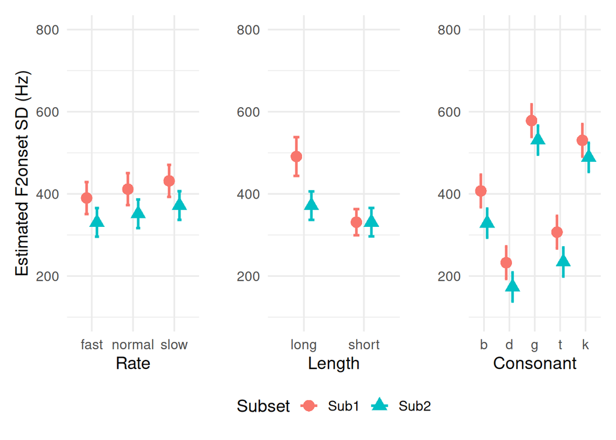

```r
# transform to dataframe
emm_sd_dfons1_rate <- as.data.frame(emm_sdons1_rate$emmeans)
emm_sd_dfons2_rate <- as.data.frame(emm_sdons2_rate$emmeans)
emm_sd_dfons1_length <- as.data.frame(emm_sdons1_length$emmeans)
emm_sd_dfons2_length <- as.data.frame(emm_sdons2_length$emmeans)
emm_sd_dfons1_C <- as.data.frame(emm_sdons1_C$emmeans)
emm_sd_dfons2_C <- as.data.frame(emm_sdons2_C$emmeans)

# to have both subsets in the same figure, we create one dataframe for both subsets for each variable:
#Rate
emm_sd_dfons1_rate$Subset <- "Sub1"
emm_sd_dfons2_rate$Subset <- "Sub2"
df_rate <- rbind(emm_sd_dfons1_rate, emm_sd_dfons2_rate)
#Length
emm_sd_dfons1_length$Subset <- "Sub1"
emm_sd_dfons2_length$Subset <- "Sub2"
df_length <- rbind(emm_sd_dfons1_length, emm_sd_dfons2_length)
#Length
emm_sd_dfons1_C$Subset <- "Sub1"
emm_sd_dfons2_C$Subset <- "Sub2"
df_C <- rbind(emm_sd_dfons1_C, emm_sd_dfons2_C)

#  Création des graphiques pour Sub1 uniquement
# p_rate1 <- ggplot(emm_sd_dfons1_rate, aes(x = Rate, y = emmean, color = Rate)) +
#  geom_point(size = 4) +
#  geom_errorbar(aes(ymin = lower.CL, ymax = upper.CL), width = 0.2, linewidth = 1) +
#  labs(y = "Estimated F2onset SD (Hz)", x = "Speaking Rate") +
#  theme_minimal(base_size = 14) +
#  theme(legend.position = "none")

#p_len1 <- ggplot(emm_sd_dfons1_length, aes(x = Length, y = emmean, color = Length)) +
#  geom_point(size = 4) +
#  geom_errorbar(aes(ymin = lower.CL, ymax = upper.CL), width = 0.2, linewidth = 1) +
#  labs(y = "", x = "Vowel Length") +
#  theme_minimal(base_size = 14) +
#  theme(legend.position = "none")

#p_C1 <- ggplot(emm_sd_dfons1_C, aes(x = C, y = emmean, color = C)) +
#  geom_point(size = 4) +
#  geom_errorbar(aes(ymin = lower.CL, ymax = upper.CL), width = 0.2, linewidth = 1) +
#  labs(y = "", x = "Consonant Context") +
#  theme_minimal(base_size = 14) +
#  theme(legend.position = "none")
## y-axe min max
#limites_Y <- c(100, 800)

## linking figures for Sub1 with patchwork
#plot_sub1 <- (p_rate1 | p_len1 | p_C1) +
#  plot_annotation(theme = theme(plot.title = element_text(size = 16, face = "bold"))) &
#  scale_y_continuous(limits = limites_Y)
#plot_sub1

###
# Figure with both subsets combined

dodge <- position_dodge(width = 0.5)

p_rate <- ggplot(df_rate, aes(x = Rate, y = emmean, color = Subset, shape = Subset)) +
  geom_point(position = dodge, size = 4) +
  geom_errorbar(aes(ymin = lower.CL, ymax = upper.CL), position = dodge, width = 0.2, linewidth = 1) +
  labs(y = "Estimated F2onset SD (Hz)", x = "Rate") +
  theme_minimal(base_size = 14)

p_length <- ggplot(df_length, aes(x = Length, y = emmean, color = Subset, shape = Subset)) +  geom_point(position = dodge, size = 4) +
  geom_errorbar(aes(ymin = lower.CL, ymax = upper.CL), position = dodge, width = 0.2, linewidth = 1) +
  labs(y = "", x = "Length") +
  theme_minimal(base_size = 14)

p_C <- ggplot(df_C, aes(x = C, y = emmean, color = Subset, shape = Subset)) +
  geom_point(position = dodge, size = 4) +
  geom_errorbar(aes(ymin = lower.CL, ymax = upper.CL), position = dodge, width = 0.2, linewidth = 1) +
  labs(y = "", x = "Consonant") +
  theme_minimal(base_size = 14)

# linking the three variables using Patchwork

plot_combined <- (p_rate | p_length | p_C) +
  plot_layout(guides = "collect") +
  plot_annotation(theme = theme(plot.title = element_text(size = 16, face = "bold"))
  ) &
  theme(legend.position = "bottom") &
  scale_y_continuous(limits = c(100, 800))

plot_combined
```

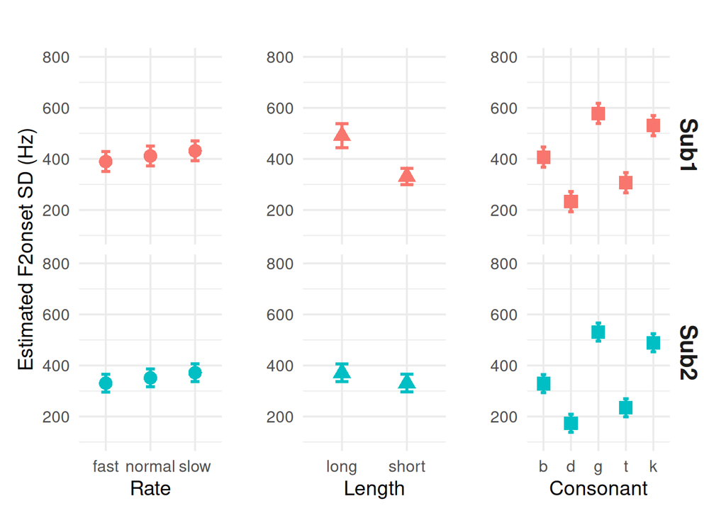

```r
################ Figure 2 ##### separate the two subsets inside the figure (more representative and clearer):
# Rate
p_rate2 <- ggplot(df_rate, aes(x = Rate, y = emmean, color = Subset)) +
  geom_point(shape = 16, size = 4) + #16=circle
  geom_errorbar(aes(ymin = lower.CL, ymax = upper.CL), width = 0.2, linewidth = 1) +
  facet_grid(Subset ~ .) +
  labs(y = "Estimated F2onset SD (Hz)", x = "Rate") +
  theme_minimal(base_size = 14) +
  theme(
    legend.position = "none",
    strip.text.y = element_blank(),
    strip.background.y = element_blank()
  )

# Length
p_length2 <- ggplot(df_length, aes(x = Length, y = emmean, color = Subset)) +
  geom_point(shape = 17, size = 4) + #17=triangle
  geom_errorbar(aes(ymin = lower.CL, ymax = upper.CL), width = 0.2, linewidth = 1) +
  facet_grid(Subset ~ .) +
  labs(y = "", x = "Length") +
  theme_minimal(base_size = 14) +
  theme(
    legend.position = "none",
    strip.text.y = element_blank(),
    strip.background.y = element_blank()
  )

# C
p_C2 <- ggplot(df_C, aes(x = C, y = emmean, color = Subset)) +
  geom_point(shape = 15, size = 4) + #15=square
  geom_errorbar(aes(ymin = lower.CL, ymax = upper.CL), width = 0.2, linewidth = 1) +
  facet_grid(Subset ~ .) +
  labs(y = "", x = "Consonant") +
  theme_minimal(base_size = 14) +
  theme(
    legend.position = "none",
    strip.text.y = element_text(size = 16, face = "bold") #
  )

# linking the 3 variables with Patchwork
plot_combined2 <- (p_rate2 | p_length2 | p_C2) +
  plot_annotation(
    title = "",
    theme = theme(plot.title = element_text(size = 16, face = "bold"))
  ) &
  scale_y_continuous(limits = c(100, 800))

plot_combined2
```

```r
##save the figure in tiff & png with high quality
#ggsave("F2onset_SD_EMMEANS.tiff", width = 12, height = 8, dpi = 1300, compression = "lzw")
#ggsave("F2onset_SD_EMMEANS.png", width = 12, height = 8, dpi = 1300)
```

# 3 LMMs Model selection : F2mid

## 3.1 Sub1

```r
lm.3.mod.1 <- lmer(F2midSD ~ Rate * Length * C + Sex + (1 | Speaker), Arabicsub1_sd, control = lmerControl(optimizer = "bobyqa", optCtrl = list(maxfun = 2e5)), REML = FALSE)
lm.3.mod.2 <- lmer(F2midSD ~ Rate * Length * C + Sex + (1 + Rate | Speaker), Arabicsub1_sd, control = lmerControl(optimizer = "bobyqa", optCtrl = list(maxfun = 2e5)), REML = FALSE)
```

```
## boundary (singular) fit: see help('isSingular')
```

```r
lm.3.mod.3 <- lmer(F2midSD ~ Rate * Length * C + Sex + (1 + Length | Speaker), Arabicsub1_sd, control = lmerControl(optimizer = "bobyqa", optCtrl = list(maxfun = 2e5)), REML = FALSE)
lm.3.mod.4 <- lmer(F2midSD ~ Rate * Length * C + Sex + (1 + C | Speaker), Arabicsub1_sd, control = lmerControl(optimizer = "bobyqa", optCtrl = list(maxfun = 2e5)), REML = FALSE)
```

```
## boundary (singular) fit: see help('isSingular')
```

```r
lm.3.mod.5 <- lmer(F2midSD ~ Rate * Length * C + Sex + (1 + Rate + Length | Speaker), Arabicsub1_sd, control = lmerControl(optimizer = "bobyqa", optCtrl = list(maxfun = 2e5)), REML = FALSE)
```

```
## boundary (singular) fit: see help('isSingular')
```

```r
lm.3.mod.6 <- lmer(F2midSD ~ Rate * Length * C + Sex + (1 + Rate + C| Speaker), Arabicsub1_sd, control = lmerControl(optimizer = "bobyqa", optCtrl = list(maxfun = 2e5)), REML = FALSE)
```

```
## boundary (singular) fit: see help('isSingular')
```

```r
lm.3.mod.7 <- lmer(F2midSD ~ Rate * Length * C + Sex + (1 + Length + C | Speaker), Arabicsub1_sd, control = lmerControl(optimizer = "bobyqa", optCtrl = list(maxfun = 2e5)), REML = FALSE)
```

```
## boundary (singular) fit: see help('isSingular')
```

```r
lm.3.mod.8 <- lmer(F2midSD ~ Rate * Length * C + Sex + (1 + Rate + Length + C | Speaker), Arabicsub1_sd, control = lmerControl(optimizer = "bobyqa", optCtrl = list(maxfun = 2e5)), REML = FALSE)
```

```
## boundary (singular) fit: see help('isSingular')
```

```r
lm.3.mod.9 <- lmer(F2midSD ~ Rate + Length + C + Sex + (1 | Speaker), Arabicsub1_sd, control = lmerControl(optimizer = "bobyqa", optCtrl = list(maxfun = 2e5)), REML = FALSE)
lm.3.mod.10 <- lmer(F2midSD ~ Rate + Length + C+ Sex + (1 + Length | Speaker), Arabicsub1_sd, control = lmerControl(optimizer = "bobyqa", optCtrl = list(maxfun = 2e5)), REML = FALSE)
lm.3.mod.11 <- lmer(F2midSD ~ Rate + Length + C +Sex + (1 + Rate | Speaker), Arabicsub1_sd, control = lmerControl(optimizer = "bobyqa", optCtrl = list(maxfun = 2e5)), REML = FALSE)
```

```
## boundary (singular) fit: see help('isSingular')
```

```r
lm.3.mod.12 <- lmer(F2midSD ~ Rate + Length + C +Sex + (1 + C | Speaker), Arabicsub1_sd, control = lmerControl(optimizer = "bobyqa", optCtrl = list(maxfun = 2e5)), REML = FALSE)
```

```
## boundary (singular) fit: see help('isSingular')
```

The models without singularity issues are lm.3.mod.1,lm.3.mod.3, lm.3.mod.9, and lm.3.mod.10.

```r
#Compairing models:

anova(lm.3.mod.1,lm.3.mod.3, lm.3.mod.9, lm.3.mod.10)
```

```
## Data: Arabicsub1_sd
## Models:
## lm.3.mod.9: F2midSD ~ Rate + Length + C + Sex + (1 | Speaker)
## lm.3.mod.10: F2midSD ~ Rate + Length + C + Sex + (1 + Length | Speaker)
## lm.3.mod.1: F2midSD ~ Rate * Length * C + Sex + (1 | Speaker)
## lm.3.mod.3: F2midSD ~ Rate * Length * C + Sex + (1 + Length | Speaker)
##             npar    AIC    BIC  logLik -2*log(L)  Chisq Df Pr(>Chisq)
## lm.3.mod.9    11 3294.0 3334.7 -1636.0    3272.0
## lm.3.mod.10   13 3256.8 3305.0 -1615.4    3230.8 41.161  2  1.153e-09 ***
## lm.3.mod.1    33 3266.5 3388.7 -1600.3    3200.5 30.322 20     0.0648 .
## lm.3.mod.3    35 3212.3 3341.9 -1571.2    3142.3 58.214  2  2.286e-13 ***
## ---
## Signif. codes:  0 '***' 0.001 '**' 0.01 '*' 0.05 '.' 0.1 ' ' 1
```

The optimal model is model 3 (the smallest AIC). A model with interaction between Rate, Length and C.

```r
# updating the optimal model with REML=TRUE.

lm.3.mod.Optimal1 <- update(lm.3.mod.3, REML = TRUE)
```

```r
#LMM summary
summary(lm.3.mod.Optimal1)
```

```
## Linear mixed model fit by REML. t-tests use Satterthwaite's method [
## lmerModLmerTest]
## Formula: F2midSD ~ Rate * Length * C + Sex + (1 + Length | Speaker)
##    Data: Arabicsub1_sd
## Control: lmerControl(optimizer = "bobyqa", optCtrl = list(maxfun = 2e+05))
##
## REML criterion at convergence: 2917.1
##
## Scaled residuals:
##     Min      1Q  Median      3Q     Max
## -3.3382 -0.5494 -0.0150  0.6402  3.0148
##
## Random effects:
##  Groups   Name        Variance Std.Dev. Corr
##  Speaker  (Intercept) 7952     89.17
##           Lengthshort 2106     45.89    -0.90
##  Residual             1914     43.75
## Number of obs: 300, groups:  Speaker, 10
##
## Fixed effects:
##                           Estimate Std. Error       df t value Pr(>|t|)
## (Intercept)                578.783     34.428   14.322  16.811 7.89e-11 ***
## Ratenormal                  27.505     19.566  252.000   1.406 0.161021
## Rateslow                    83.064     19.566  252.000   4.245 3.07e-05 ***
## Lengthshort               -270.956     24.360   52.545 -11.123 2.01e-15 ***
## Cd                         -85.916     19.566  252.000  -4.391 1.66e-05 ***
## Cg                         -41.860     19.566  252.000  -2.139 0.033361 *
## Ct                         -37.257     19.566  252.000  -1.904 0.058026 .
## Ck                         -67.770     19.566  252.000  -3.464 0.000626 ***
## Sexm                        -1.747     28.192    8.000  -0.062 0.952100
## Ratenormal:Lengthshort      21.179     27.670  252.000   0.765 0.444733
## Rateslow:Lengthshort       -18.237     27.670  252.000  -0.659 0.510444
## Ratenormal:Cd               62.045     27.670  252.000   2.242 0.025811 *
## Rateslow:Cd                 68.288     27.670  252.000   2.468 0.014254 *
## Ratenormal:Cg               38.497     27.670  252.000   1.391 0.165362
## Rateslow:Cg                 37.772     27.670  252.000   1.365 0.173439
## Ratenormal:Ct               39.082     27.670  252.000   1.412 0.159062
## Rateslow:Ct                 19.162     27.670  252.000   0.693 0.489245
## Ratenormal:Ck               28.869     27.670  252.000   1.043 0.297801
## Rateslow:Ck                 51.239     27.670  252.000   1.852 0.065225 .
## Lengthshort:Cd               6.083     27.670  252.000   0.220 0.826174
## Lengthshort:Cg              85.331     27.670  252.000   3.084 0.002271 **
## Lengthshort:Ct              17.918     27.670  252.000   0.648 0.517851
## Lengthshort:Ck              69.625     27.670  252.000   2.516 0.012483 *
## Ratenormal:Lengthshort:Cd  -99.431     39.131  252.000  -2.541 0.011656 *
## Rateslow:Lengthshort:Cd    -90.337     39.131  252.000  -2.309 0.021778 *
## Ratenormal:Lengthshort:Cg  -48.487     39.131  252.000  -1.239 0.216468
## Rateslow:Lengthshort:Cg    -48.300     39.131  252.000  -1.234 0.218238
## Ratenormal:Lengthshort:Ct  -46.592     39.131  252.000  -1.191 0.234913
## Rateslow:Lengthshort:Ct    -27.415     39.131  252.000  -0.701 0.484199
## Ratenormal:Lengthshort:Ck  -62.999     39.131  252.000  -1.610 0.108663
## Rateslow:Lengthshort:Ck    -62.691     39.131  252.000  -1.602 0.110392
## ---
## Signif. codes:  0 '***' 0.001 '**' 0.01 '*' 0.05 '.' 0.1 ' ' 1
```

```
##
## Correlation matrix not shown by default, as p = 31 > 12.
## Use print(x, correlation=TRUE)  or
##     vcov(x)        if you need it
```

```r
# LMM anova
anova(lm.3.mod.Optimal1)
```

```
## Type III Analysis of Variance Table with Satterthwaite's method
##               Sum Sq Mean Sq NumDF DenDF  F value    Pr(>F)
## Rate          373476  186738     2   252  97.5601 < 2.2e-16 ***
## Length        576135  576135     1     9 300.9977 3.169e-08 ***
## C             236917   59229     4   252  30.9439 < 2.2e-16 ***
## Sex                7       7     1     8   0.0038    0.9521
## Rate:Length    51224   25612     2   252  13.3807 3.000e-06 ***
## Rate:C          8674    1084     8   252   0.5664    0.8050
## Length:C      102638   25660     4   252  13.4056 6.410e-10 ***
## Rate:Length:C  16851    2106     8   252   1.1005    0.3633
## ---
## Signif. codes:  0 '***' 0.001 '**' 0.01 '*' 0.05 '.' 0.1 ' ' 1
```

## 3.2 Sub2

```r
lm.4.mod.1 <- lmer(F2midSD ~ Rate * Length * C + Sex + (1 | Speaker), Arabicsub2_sd, control = lmerControl(optimizer = "bobyqa", optCtrl = list(maxfun = 2e5)), REML = FALSE)
lm.4.mod.2 <- lmer(F2midSD ~ Rate * Length * C + Sex + (1 + Rate | Speaker), Arabicsub2_sd, control = lmerControl(optimizer = "bobyqa", optCtrl = list(maxfun = 2e5)), REML = FALSE)
```

```
## boundary (singular) fit: see help('isSingular')
```

```r
lm.4.mod.3 <- lmer(F2midSD ~ Rate * Length * C + Sex + (1 + Length | Speaker), Arabicsub2_sd, control = lmerControl(optimizer = "bobyqa", optCtrl = list(maxfun = 2e5)), REML = FALSE)
lm.4.mod.4 <- lmer(F2midSD ~ Rate * Length * C + Sex + (1 + C | Speaker), Arabicsub2_sd, control = lmerControl(optimizer = "bobyqa", optCtrl = list(maxfun = 2e5)), REML = FALSE)
```

```
## boundary (singular) fit: see help('isSingular')
```

```r
lm.4.mod.5 <- lmer(F2midSD ~ Rate * Length * C + Sex + (1 + Rate + Length | Speaker), Arabicsub2_sd, control = lmerControl(optimizer = "bobyqa", optCtrl = list(maxfun = 2e5)), REML = FALSE)
```

```
## boundary (singular) fit: see help('isSingular')
```

```r
lm.4.mod.6 <- lmer(F2midSD ~ Rate * Length * C + Sex + (1 + Rate + C| Speaker), Arabicsub2_sd, control = lmerControl(optimizer = "bobyqa", optCtrl = list(maxfun = 2e5)), REML = FALSE)
```

```
## boundary (singular) fit: see help('isSingular')
```

```r
lm.4.mod.7 <- lmer(F2midSD ~ Rate * Length * C + Sex + (1 + Length + C | Speaker), Arabicsub2_sd, control = lmerControl(optimizer = "bobyqa", optCtrl = list(maxfun = 2e5)), REML = FALSE)
lm.4.mod.8 <- lmer(F2midSD ~ Rate * Length * C + Sex + (1 + Rate + Length + C | Speaker), Arabicsub2_sd, control = lmerControl(optimizer = "bobyqa", optCtrl = list(maxfun = 2e5)), REML = FALSE)
```

```
## boundary (singular) fit: see help('isSingular')
```

```r
lm.4.mod.9 <- lmer(F2midSD ~ Rate + Length + C + Sex + (1 | Speaker), Arabicsub2_sd, control = lmerControl(optimizer = "bobyqa", optCtrl = list(maxfun = 2e5)), REML = FALSE)
lm.4.mod.10 <- lmer(F2midSD ~ Rate + Length + C+ Sex + (1 + Length | Speaker), Arabicsub2_sd, control = lmerControl(optimizer = "bobyqa", optCtrl = list(maxfun = 2e5)), REML = FALSE)
lm.4.mod.11 <- lmer(F2midSD ~ Rate + Length + C +Sex + (1 + Rate | Speaker), Arabicsub2_sd, control = lmerControl(optimizer = "bobyqa", optCtrl = list(maxfun = 2e5)), REML = FALSE)
```

```
## boundary (singular) fit: see help('isSingular')
```

```r
lm.4.mod.12 <- lmer(F2midSD ~ Rate + Length + C +Sex + (1 + C | Speaker), Arabicsub2_sd, control = lmerControl(optimizer = "bobyqa", optCtrl = list(maxfun = 2e5)), REML = FALSE)
```

```
## boundary (singular) fit: see help('isSingular')
```

The models lm.4.mod.1,lm.4.mod.3, lm.4.mod.9, and lm.4.mod.10 have no singularity issues.

```r
#Compairing models:

anova(lm.4.mod.1,lm.4.mod.3,lm.4.mod.9,lm.4.mod.10)
```

```
## Data: Arabicsub2_sd
## Models:
## lm.4.mod.9: F2midSD ~ Rate + Length + C + Sex + (1 | Speaker)
## lm.4.mod.10: F2midSD ~ Rate + Length + C + Sex + (1 + Length | Speaker)
## lm.4.mod.1: F2midSD ~ Rate * Length * C + Sex + (1 | Speaker)
## lm.4.mod.3: F2midSD ~ Rate * Length * C + Sex + (1 + Length | Speaker)
##             npar    AIC    BIC  logLik -2*log(L)  Chisq Df Pr(>Chisq)
## lm.4.mod.9    11 3217.2 3257.9 -1597.6    3195.2
## lm.4.mod.10   13 3184.5 3232.7 -1579.2    3158.5 36.703  2  1.071e-08 ***
## lm.4.mod.1    33 3204.2 3326.4 -1569.1    3138.2 20.324 20     0.4378
## lm.4.mod.3    35 3157.3 3286.9 -1543.6    3087.3 50.892  2  8.890e-12 ***
## ---
## Signif. codes:  0 '***' 0.001 '**' 0.01 '*' 0.05 '.' 0.1 ' ' 1
```

The optimal model is model 3 (the smallest AIC). A model with interaction between Rate, Length, and C.

```r
# updating the optimal model with REML=TRUE.

lm.4.mod.Optimal1 <- update(lm.4.mod.3, REML = TRUE)
```

```r
#LMM summary
summary(lm.4.mod.Optimal1)
```

```
## Linear mixed model fit by REML. t-tests use Satterthwaite's method [
## lmerModLmerTest]
## Formula: F2midSD ~ Rate * Length * C + Sex + (1 + Length | Speaker)
##    Data: Arabicsub2_sd
## Control: lmerControl(optimizer = "bobyqa", optCtrl = list(maxfun = 2e+05))
##
## REML criterion at convergence: 2867.4
##
## Scaled residuals:
##     Min      1Q  Median      3Q     Max
## -2.6728 -0.5651 -0.0312  0.6102  3.5198
##
## Random effects:
##  Groups   Name        Variance Std.Dev. Corr
##  Speaker  (Intercept) 2989     54.67
##           Lengthshort 1744     41.76    -0.47
##  Residual             1573     39.66
## Number of obs: 300, groups:  Speaker, 10
##
## Fixed effects:
##                           Estimate Std. Error      df t value Pr(>|t|)
## (Intercept)                406.053     26.345  14.593  15.413 1.97e-10 ***
## Ratenormal                  36.115     17.738 252.000   2.036 0.042792 *
## Rateslow                    91.658     17.738 252.000   5.167 4.83e-07 ***
## Lengthshort                -79.216     22.114  52.169  -3.582 0.000748 ***
## Cd                         -73.062     17.738 252.000  -4.119 5.16e-05 ***
## Cg                         -15.790     17.738 252.000  -0.890 0.374198
## Ct                         -55.418     17.738 252.000  -3.124 0.001991 **
## Ck                         -45.664     17.738 252.000  -2.574 0.010613 *
## Sexm                       -39.767     30.845   8.000  -1.289 0.233335
## Ratenormal:Lengthshort      12.570     25.085 252.000   0.501 0.616742
## Rateslow:Lengthshort       -26.831     25.085 252.000  -1.070 0.285813
## Ratenormal:Cd               25.786     25.085 252.000   1.028 0.304952
## Rateslow:Cd                 33.504     25.085 252.000   1.336 0.182879
## Ratenormal:Cg               22.125     25.085 252.000   0.882 0.378605
## Rateslow:Cg                 23.236     25.085 252.000   0.926 0.355172
## Ratenormal:Ct               11.007     25.085 252.000   0.439 0.661202
## Rateslow:Ct                 12.101     25.085 252.000   0.482 0.629932
## Ratenormal:Ck                3.085     25.085 252.000   0.123 0.902207
## Rateslow:Ck                 13.874     25.085 252.000   0.553 0.580698
## Lengthshort:Cd              -6.771     25.085 252.000  -0.270 0.787432
## Lengthshort:Cg              59.262     25.085 252.000   2.362 0.018915 *
## Lengthshort:Ct              36.080     25.085 252.000   1.438 0.151585
## Lengthshort:Ck              47.519     25.085 252.000   1.894 0.059325 .
## Ratenormal:Lengthshort:Cd  -63.172     35.475 252.000  -1.781 0.076160 .
## Rateslow:Lengthshort:Cd    -55.552     35.475 252.000  -1.566 0.118617
## Ratenormal:Lengthshort:Cg  -32.115     35.475 252.000  -0.905 0.366183
## Rateslow:Lengthshort:Cg    -33.764     35.475 252.000  -0.952 0.342130
## Ratenormal:Lengthshort:Ct  -18.517     35.475 252.000  -0.522 0.602159
## Rateslow:Lengthshort:Ct    -20.354     35.475 252.000  -0.574 0.566640
## Ratenormal:Lengthshort:Ck  -37.216     35.475 252.000  -1.049 0.295154
## Rateslow:Lengthshort:Ck    -25.326     35.475 252.000  -0.714 0.475946
## ---
## Signif. codes:  0 '***' 0.001 '**' 0.01 '*' 0.05 '.' 0.1 ' ' 1
```

```
##
## Correlation matrix not shown by default, as p = 31 > 12.
## Use print(x, correlation=TRUE)  or
##     vcov(x)        if you need it
```

```r
# LMM anova
anova(lm.4.mod.Optimal1)
```

```
## Type III Analysis of Variance Table with Satterthwaite's method
##               Sum Sq Mean Sq NumDF DenDF  F value    Pr(>F)
## Rate          330429  165214     2   252 105.0227 < 2.2e-16 ***
## Length         46282   46282     1     9  29.4200 0.0004196 ***
## C             314775   78694     4   252  50.0237 < 2.2e-16 ***
## Sex             2615    2615     1     8   1.6622 0.2333347
## Rate:Length    37658   18829     2   252  11.9690 1.082e-05 ***
## Rate:C          3720     465     8   252   0.2956 0.9670196
## Length:C       66801   16700     4   252  10.6159 5.769e-08 ***
## Rate:Length:C   6633     829     8   252   0.5270 0.8356983
## ---
## Signif. codes:  0 '***' 0.001 '**' 0.01 '*' 0.05 '.' 0.1 ' ' 1
```

## 3.3 Estimated Marginal Means (EMMs)

```r
# The interactions rate:length & C:length were significant. We test these double interactions :

# effect of rate according to length
emm_mid1_rate_length <- emmeans(lm.3.mod.Optimal1, pairwise ~ Rate | Length) # Sub1
```

```
## NOTE: Results may be misleading due to involvement in interactions
```

```r
emm_mid2_rate_length <- emmeans(lm.4.mod.Optimal1, pairwise ~ Rate | Length) # Sub2
```

```
## NOTE: Results may be misleading due to involvement in interactions
```

```r
# effect on C according to length
emm_mid1_C_length <- emmeans(lm.3.mod.Optimal1, pairwise ~ C | Length) # Sub1
```

```
## NOTE: Results may be misleading due to involvement in interactions
```

```r
emm_mid2_C_length <- emmeans(lm.4.mod.Optimal1, pairwise ~ C | Length) # Sub2
```

```
## NOTE: Results may be misleading due to involvement in interactions
```

```r
#  showing contrasts
emm_mid1_rate_length$contrasts
```

```
## Length = long:
##  contrast      estimate   SE  df t.ratio p.value
##  fast - normal    -61.2 8.75 252  -6.995 <0.0001
##  fast - slow     -118.4 8.75 252 -13.526 <0.0001
##  normal - slow    -57.2 8.75 252  -6.532 <0.0001
##
## Length = short:
##  contrast      estimate   SE  df t.ratio p.value
##  fast - normal    -30.9 8.75 252  -3.529  0.0014
##  fast - slow      -54.4 8.75 252  -6.214 <0.0001
##  normal - slow    -23.5 8.75 252  -2.684  0.0211
##
## Results are averaged over the levels of: C, Sex
## Degrees-of-freedom method: kenward-roger
## P value adjustment: tukey method for comparing a family of 3 estimates
```

```r
emm_mid2_rate_length$contrasts
```

```
## Length = long:
##  contrast      estimate   SE  df t.ratio p.value
##  fast - normal    -48.5 7.93 252  -6.116 <0.0001
##  fast - slow     -108.2 7.93 252 -13.640 <0.0001
##  normal - slow    -59.7 7.93 252  -7.524 <0.0001
##
## Length = short:
##  contrast      estimate   SE  df t.ratio p.value
##  fast - normal    -30.9 7.93 252  -3.893  0.0004
##  fast - slow      -54.4 7.93 252  -6.854 <0.0001
##  normal - slow    -23.5 7.93 252  -2.961  0.0094
##
## Results are averaged over the levels of: C, Sex
## Degrees-of-freedom method: kenward-roger
## P value adjustment: tukey method for comparing a family of 3 estimates
```

```r
emm_mid1_C_length$contrasts
```

```
## Length = long:
##  contrast estimate   SE  df t.ratio p.value
##  b - d       42.47 11.3 252   3.760  0.0020
##  b - g       16.44 11.3 252   1.455  0.5927
##  b - t       17.84 11.3 252   1.579  0.5120
##  b - k       41.07 11.3 252   3.635  0.0031
##  d - g      -26.04 11.3 252  -2.305  0.1467
##  d - t      -24.63 11.3 252  -2.180  0.1905
##  d - k       -1.40 11.3 252  -0.124  0.9999
##  g - t        1.41 11.3 252   0.124  0.9999
##  g - k       24.63 11.3 252   2.180  0.1905
##  t - k       23.22 11.3 252   2.056  0.2427
##
## Length = short:
##  contrast estimate   SE  df t.ratio p.value
##  b - d       99.64 11.3 252   8.821 <0.0001
##  b - g      -36.63 11.3 252  -3.243  0.0116
##  b - t       24.59 11.3 252   2.177  0.1918
##  b - k       13.34 11.3 252   1.181  0.7624
##  d - g     -136.28 11.3 252 -12.064 <0.0001
##  d - t      -75.05 11.3 252  -6.644 <0.0001
##  d - k      -86.31 11.3 252  -7.640 <0.0001
##  g - t       61.23 11.3 252   5.420 <0.0001
##  g - k       49.97 11.3 252   4.424  0.0001
##  t - k      -11.25 11.3 252  -0.996  0.8569
##
## Results are averaged over the levels of: Rate, Sex
## Degrees-of-freedom method: kenward-roger
## P value adjustment: tukey method for comparing a family of 5 estimates
```

```r
emm_mid2_C_length$contrasts
```

```
## Length = long:
##  contrast estimate   SE  df t.ratio p.value
##  b - d       53.30 10.2 252   5.205 <0.0001
##  b - g        0.67 10.2 252   0.065  1.0000
##  b - t       47.72 10.2 252   4.659 <0.0001
##  b - k       40.01 10.2 252   3.907  0.0011
##  d - g      -52.63 10.2 252  -5.139 <0.0001
##  d - t       -5.58 10.2 252  -0.545  0.9824
##  d - k      -13.29 10.2 252  -1.298  0.6930
##  g - t       47.05 10.2 252   4.594 <0.0001
##  g - k       39.34 10.2 252   3.842  0.0014
##  t - k       -7.70 10.2 252  -0.752  0.9437
##
## Length = short:
##  contrast estimate   SE  df t.ratio p.value
##  b - d       99.64 10.2 252   9.730 <0.0001
##  b - g      -36.63 10.2 252  -3.577  0.0038
##  b - t       24.59 10.2 252   2.401  0.1183
##  b - k       13.34 10.2 252   1.303  0.6899
##  d - g     -136.28 10.2 252 -13.307 <0.0001
##  d - t      -75.05 10.2 252  -7.329 <0.0001
##  d - k      -86.31 10.2 252  -8.428 <0.0001
##  g - t       61.23 10.2 252   5.979 <0.0001
##  g - k       49.97 10.2 252   4.880 <0.0001
##  t - k      -11.25 10.2 252  -1.099  0.8070
##
## Results are averaged over the levels of: Rate, Sex
## Degrees-of-freedom method: kenward-roger
## P value adjustment: tukey method for comparing a family of 5 estimates
```

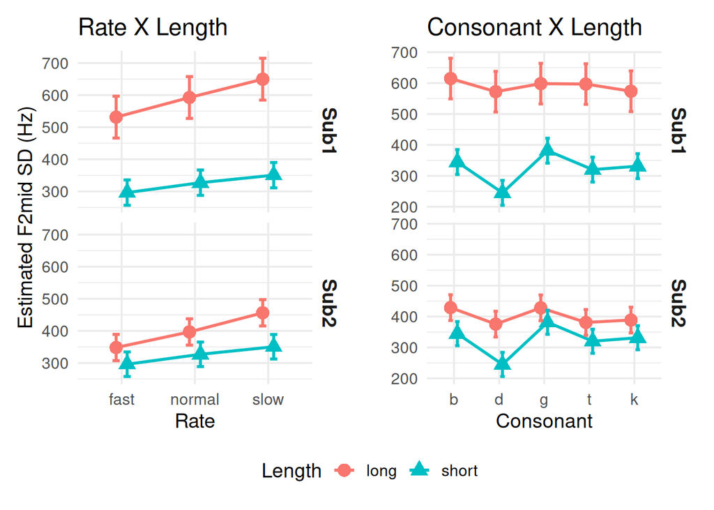

```r
#####

# create a dataframe for each interaction for each subset and then bind both sub in the same dataframe :
# interaction Rate * Length
emm_RL1 <- as.data.frame(emm_mid1_rate_length$emmeans) %>% mutate(Subset = "Sub1")
emm_RL2 <- as.data.frame(emm_mid2_rate_length$emmeans) %>% mutate(Subset = "Sub2")
df_RL <- bind_rows(emm_RL1, emm_RL2)

# interaction C * Length
emm_CL1 <- as.data.frame(emm_mid1_C_length$emmeans) %>% mutate(Subset = "Sub1")
emm_CL2 <- as.data.frame(emm_mid2_C_length$emmeans) %>% mutate(Subset = "Sub2")
df_CL <- bind_rows(emm_CL1, emm_CL2)

# Figures
dodge <- position_dodge(width = 0.3)

plot_RL <- ggplot(df_RL, aes(x = Rate, y = emmean, color = Length, group = Length, shape = Length)) +
  geom_point(position = dodge, size = 4) +
  geom_line(position = dodge, linewidth = 1) +
  geom_errorbar(aes(ymin = lower.CL, ymax = upper.CL), position = dodge, width = 0.2, linewidth = 1) +
  facet_grid(Subset ~ .) +
  labs(y = "Estimated F2mid SD (Hz)", x = "Rate", title = "Rate X Length") +
  theme_minimal(base_size = 14) +
  theme(strip.text.y = element_text(size = 14, face = "bold"))

plot_CL <- ggplot(df_CL, aes(x = C, y = emmean, color = Length, group = Length, shape = Length)) +
  geom_point(position = dodge, size = 4) +
  geom_line(position = dodge, linewidth = 1) +
  geom_errorbar(aes(ymin = lower.CL, ymax = upper.CL), position = dodge, width = 0.2, linewidth = 1) +
  facet_grid(Subset ~ .) +
  labs(y = "", x = "Consonant", title = "Consonant X Length") +
  theme_minimal(base_size = 14) +
  theme(strip.text.y = element_text(size = 14, face = "bold"))

# linking figures
plot_interactions <- (plot_RL | plot_CL) +
  plot_layout(guides = "collect") +
  plot_annotation(theme = theme(plot.title = element_text(size = 16, face = "bold"))) &
  theme(legend.position = "bottom")

plot_interactions
```

```r
#  EMMs pour chaque C avec toutes les combinaisons  * Length * Rate

emm_sdmid1  <- emmeans(lm.3.mod.Optimal1,  ~  Rate * Length | C) #Sub1
emm_sdmid2  <- emmeans(lm.4.mod.Optimal1,  ~  Rate * Length | C) #Sub2
# Résumé sous forme de dataframe
emm_sd_dfmid1 <- as.data.frame(emm_sdmid1)
emm_sd_dfmid2 <- as.data.frame(emm_sdmid2)
# Comparaismid par paire de Rate × Length pour chaque C
#Sub1
pairs(emm_sdmid1, by = "C", adjust = "tukey")
```

```
## C = b:
##  contrast                   estimate   SE    df t.ratio p.value
##  fast long - normal long       -27.5 19.6 252.0  -1.406  0.7235
##  fast long - slow long         -83.1 19.6 252.0  -4.245  0.0004
##  fast long - fast short        271.0 24.4  52.5  11.123 <0.0001
##  fast long - normal short      222.3 24.4  52.5   9.124 <0.0001
##  fast long - slow short        206.1 24.4  52.5   8.462 <0.0001
##  normal long - slow long       -55.6 19.6 252.0  -2.840  0.0546
##  normal long - fast short      298.5 24.4  52.5  12.252 <0.0001
##  normal long - normal short    249.8 24.4  52.5  10.253 <0.0001
##  normal long - slow short      233.6 24.4  52.5   9.591 <0.0001
##  slow long - fast short        354.0 24.4  52.5  14.533 <0.0001
##  slow long - normal short      305.3 24.4  52.5  12.534 <0.0001
##  slow long - slow short        289.2 24.4  52.5  11.871 <0.0001
##  fast short - normal short     -48.7 19.6 252.0  -2.488  0.1315
##  fast short - slow short       -64.8 19.6 252.0  -3.313  0.0134
##  normal short - slow short     -16.1 19.6 252.0  -0.825  0.9627
##
## C = d:
##  contrast                   estimate   SE    df t.ratio p.value
##  fast long - normal long       -89.6 19.6 252.0  -4.577  0.0001
##  fast long - slow long        -151.4 19.6 252.0  -7.736 <0.0001
##  fast long - fast short        264.9 24.4  52.5  10.873 <0.0001
##  fast long - normal short      253.6 24.4  52.5  10.409 <0.0001
##  fast long - slow short        222.1 24.4  52.5   9.117 <0.0001
##  normal long - slow long       -61.8 19.6 252.0  -3.159  0.0217
##  normal long - fast short      354.4 24.4  52.5  14.549 <0.0001
##  normal long - normal short    343.1 24.4  52.5  14.085 <0.0001
##  normal long - slow short      311.6 24.4  52.5  12.793 <0.0001
##  slow long - fast short        416.2 24.4  52.5  17.086 <0.0001
##  slow long - normal short      404.9 24.4  52.5  16.622 <0.0001
##  slow long - slow short        373.4 24.4  52.5  15.330 <0.0001
##  fast short - normal short     -11.3 19.6 252.0  -0.577  0.9924
##  fast short - slow short       -42.8 19.6 252.0  -2.186  0.2478
##  normal short - slow short     -31.5 19.6 252.0  -1.609  0.5934
##
## C = g:
##  contrast                   estimate   SE    df t.ratio p.value
##  fast long - normal long       -66.0 19.6 252.0  -3.373  0.0110
##  fast long - slow long        -120.8 19.6 252.0  -6.176 <0.0001
```

[output cut: 38 more lines]

```
##  fast long - slow short        148.0 24.4  52.5   6.074 <0.0001
##  normal long - slow long       -77.9 19.6 252.0  -3.983  0.0012
##  normal long - fast short      257.7 24.4  52.5  10.579 <0.0001
##  normal long - normal short    243.2 24.4  52.5   9.981 <0.0001
##  normal long - slow short      204.3 24.4  52.5   8.388 <0.0001
##  slow long - fast short        335.6 24.4  52.5  13.778 <0.0001
##  slow long - normal short      321.1 24.4  52.5  13.180 <0.0001
##  slow long - slow short        282.3 24.4  52.5  11.587 <0.0001
##  fast short - normal short     -14.6 19.6 252.0  -0.744  0.9762
##  fast short - slow short       -53.4 19.6 252.0  -2.728  0.0733
##  normal short - slow short     -38.8 19.6 252.0  -1.984  0.3543
##
## Results are averaged over the levels of: Sex
## Degrees-of-freedom method: kenward-roger
## P value adjustment: tukey method for comparing a family of 6 estimates
```

```r
#Sub2
pairs(emm_sdmid2, by = "C", adjust = "tukey")
```

```
## C = b:
##  contrast                   estimate   SE    df t.ratio p.value
##  fast long - normal long      -36.11 17.7 252.0  -2.036  0.3249
##  fast long - slow long        -91.66 17.7 252.0  -5.167 <0.0001
##  fast long - fast short        79.22 22.1  52.2   3.582  0.0093
##  fast long - normal short      30.53 22.1  52.2   1.381  0.7382
##  fast long - slow short        14.39 22.1  52.2   0.651  0.9864
##  normal long - slow long      -55.54 17.7 252.0  -3.131  0.0236
##  normal long - fast short     115.33 22.1  52.2   5.215 <0.0001
##  normal long - normal short    66.65 22.1  52.2   3.014  0.0435
##  normal long - slow short      50.50 22.1  52.2   2.284  0.2192
##  slow long - fast short       170.87 22.1  52.2   7.727 <0.0001
##  slow long - normal short     122.19 22.1  52.2   5.525 <0.0001
##  slow long - slow short       106.05 22.1  52.2   4.795  0.0002
##  fast short - normal short    -48.68 17.7 252.0  -2.745  0.0702
##  fast short - slow short      -64.83 17.7 252.0  -3.655  0.0042
##  normal short - slow short    -16.14 17.7 252.0  -0.910  0.9437
##
## C = d:
##  contrast                   estimate   SE    df t.ratio p.value
##  fast long - normal long      -61.90 17.7 252.0  -3.490  0.0075
##  fast long - slow long       -125.16 17.7 252.0  -7.056 <0.0001
##  fast long - fast short        85.99 22.1  52.2   3.888  0.0037
##  fast long - normal short      74.69 22.1  52.2   3.377  0.0166
##  fast long - slow short        43.21 22.1  52.2   1.954  0.3823
##  normal long - slow long      -63.26 17.7 252.0  -3.566  0.0057
##  normal long - fast short     147.89 22.1  52.2   6.687 <0.0001
##  normal long - normal short   136.59 22.1  52.2   6.177 <0.0001
##  normal long - slow short     105.11 22.1  52.2   4.753  0.0002
##  slow long - fast short       211.15 22.1  52.2   9.548 <0.0001
##  slow long - normal short     199.85 22.1  52.2   9.037 <0.0001
##  slow long - slow short       168.37 22.1  52.2   7.614 <0.0001
##  fast short - normal short    -11.30 17.7 252.0  -0.637  0.9881
##  fast short - slow short      -42.78 17.7 252.0  -2.412  0.1561
##  normal short - slow short    -31.48 17.7 252.0  -1.775  0.4840
##
## C = g:
##  contrast                   estimate   SE    df t.ratio p.value
##  fast long - normal long      -58.24 17.7 252.0  -3.283  0.0147
##  fast long - slow long       -114.89 17.7 252.0  -6.477 <0.0001
```

[output cut: 38 more lines]

```
##  fast long - slow short       -21.68 22.1  52.2  -0.980  0.9222
##  normal long - slow long      -66.33 17.7 252.0  -3.740  0.0031
##  normal long - fast short      70.90 22.1  52.2   3.206  0.0264
##  normal long - normal short    56.34 22.1  52.2   2.548  0.1292
##  normal long - slow short      17.52 22.1  52.2   0.792  0.9676
##  slow long - fast short       137.23 22.1  52.2   6.205 <0.0001
##  slow long - normal short     122.68 22.1  52.2   5.547 <0.0001
##  slow long - slow short        83.85 22.1  52.2   3.792  0.0050
##  fast short - normal short    -14.55 17.7 252.0  -0.821  0.9636
##  fast short - slow short      -53.37 17.7 252.0  -3.009  0.0339
##  normal short - slow short    -38.82 17.7 252.0  -2.189  0.2467
##
## Results are averaged over the levels of: Sex
## Degrees-of-freedom method: kenward-roger
## P value adjustment: tukey method for comparing a family of 6 estimates
```

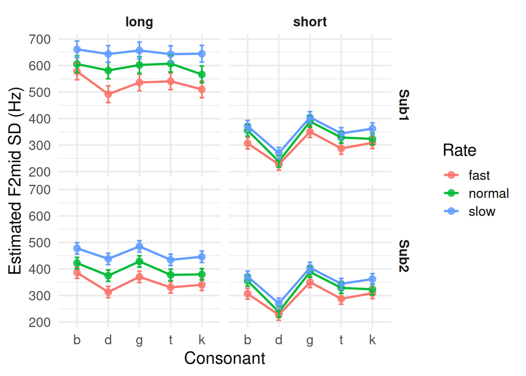

```r
### plot both subsets separately (full interaction):
#plot_mid1 <- ggplot(emm_sd_dfmid1, aes(x = C, y = emmean, color = Rate, group = Rate)) +
#     geom_point(position = position_dodge(width = 0.3), size = 3) +
#     geom_line(position = position_dodge(width = 0.3)) +
#     geom_errorbar(aes(ymin = emmean - SE, ymax = emmean + SE),
#                   width = 0.2, position = position_dodge(width = 0.3)) +
#     facet_wrap(~ Length) +
#     labs(y = "Estimated F2mid SD (Hz) Sub1", x = "Consonant",
#          color = "Speech rate") +
#     theme_minimal(base_size = 14)
#
#plot_mid1
#
#plot_mid2 <- ggplot(emm_sd_dfmid2, aes(x = C, y = emmean, color = Rate, group = Rate)) +
#     geom_point(position = position_dodge(width = 0.3), size = 3) +
#     geom_line(position = position_dodge(width = 0.3)) +
#     geom_errorbar(aes(ymin = emmean - SE, ymax = emmean + SE),
#                   width = 0.2, position = position_dodge(width = 0.3)) +
#     facet_wrap(~ Length) +
#     labs(y = "Estimated F2mid SD (Hz) Sub2", x = "Consonant",
#          color = "Speech rate") +
#     theme_minimal(base_size = 14)
#plot_mid2

# Add a column to identify subsets to have both subset on one figure
emm_sd_dfmid1 <- emm_sd_dfmid1 %>% mutate(Subset = "Sub1")
emm_sd_dfmid2 <- emm_sd_dfmid2 %>% mutate(Subset = "Sub2")

# Combine
emm_sd_allmid <- bind_rows(emm_sd_dfmid1, emm_sd_dfmid2)

plot_mid <- ggplot(emm_sd_allmid, aes(x = C, y = emmean, color = Rate, group = Rate)) +
  geom_point(#position = position_dodge(width = 0.3),
    size = 2.5, alpha=0.8) +
  geom_line(#position = position_dodge(width = 0.3)
    linewidth = 1) +
  geom_errorbar(aes(ymin = emmean - SE, ymax = emmean + SE),
                width = 0.15) +
  #, position = position_dodge(width = 0.3)) +
  facet_grid(Subset ~ Length) +  # columns = Subset (Sub1 vs Sub2), rows = Length
  labs(y = "Estimated F2mid SD (Hz)", x = "Consonant",
       color = "Rate") +
  theme_minimal(base_size = 16) +
  theme(strip.text = element_text(face = "bold"))

plot_mid
```

```r
#ggsave("F2mid_SD_EMMEANS.tiff", width = 12, height = 8, dpi = 1300, compression = "lzw")
#ggsave("F2mid_SD_EMMEANS.png", width = 12, height = 8, dpi = 1300)
```